# PERFORMANCE EVALUATION

**What this section does:**

We measure how well the model performs overall. But before we look at the numbers, there is an important warning.

**Why accuracy is not our metric, the full explanation**

Recall our class of 1,000 students with 1 cheater. A teacher who marks every student as not cheating achieves 99.9% accuracy. They catch zero cheaters.

This is the accuracy paradox. Standard accuracy is almost useless when one outcome is extremely rare. We need tools that penalise the model for missing fraud, not just for being wrong in general.

This is the deep reason why aggregate performance metrics must always be paired with per-group analysis. A model can achieve an outstanding MCC while simultaneously providing zero protection to an entire segment of users; because those users contribute so few fraud cases to the overall count that their failures barely register in the aggregate number.

We will demonstrate this precisely in the fairness and bias section.

**Metric 1: Matthews Correlation Coefficient (MCC)**

MCC accounts for all four outcomes: fraud correctly caught, legitimate correctly cleared, fraud missed, and legitimate customers wrongly blocked. Scale: negative 1 (perfectly wrong) to 0 (random guessing) to positive 1 (perfect). Our threshold: MCC above 0.50.

**Metric 2: Log Loss**

Measures both accuracy and confidence. A model that says it is 95% sure something is fraud and is wrong gets penalised far more heavily than one that says 55% sure. In fraud detection, confident wrong predictions are expensive. Our threshold: Log Loss below 0.40.

```python
# ── SECTION 1: LOAD CHECKPOINT ───────────────────────────────────────────────

import pandas as pd
import numpy as np
from scipy import stats
from sklearn.preprocessing import LabelEncoder
from scipy.stats import ks_2samp
from sklearn.metrics import matthews_corrcoef, log_loss, confusion_matrix, precision_recall_curve, auc
import matplotlib.pyplot as plt
import seaborn as sns
bins_proxy   = [-np.inf, 0.0, 50397.0, np.inf]
labels_proxy = ['Low-Balance', 'Mid-Balance', 'High-Balance']

df = pd.read_csv('checkpoint.csv')

print(f'Checkpoint loaded: {df.shape[0]:,} rows x {df.shape[1]} columns')
print(df.columns.tolist())
```

```
Checkpoint loaded: 6,362,620 rows x 11 columns
['step', 'type', 'amount', 'nameOrig', 'oldbalanceOrg', 'newbalanceOrig', 'nameDest', 'oldbalanceDest', 'newbalanceDest', 'isFraud', 'isFlaggedFraud']
```

```python
#Load Training Results Answers
import pandas as pd
results = pd.read_csv('model_results.csv')

y_test = results['y_test']
y_pred = results['y_pred']
y_prob = results['y_prob']
s_test = results[['balance_group']] # Re-creating s_test for the audit

print("All audit variables (including s_test) are now defined.")
```

```
All audit variables (including s_test) are now defined.
```

```python
# Thresholds from SETUP, THRESHOLDS AND ENVIRONMENT Notebook section
THRESHOLDS = {
    'SPD':      0.10,   # Fairness
    'EOD':      0.10,   # Fairness
    'MCC':      0.50,   # Performance
    'LOG_LOSS': 0.40,   # Performance
    'PR_AUC':   0.70,   # Performance
    'KS':       0.30,   # Performance
}
```

```
============================================================
PERFORMANCE METRICS — MCC AND LOG LOSS
============================================================

MCC      = 0.4419 | Threshold > 0.5 | FAIL
Log Loss = 0.0135 | Threshold < 0.4 | PASS

Confusion Matrix Breakdown:
  Legitimate correctly cleared :  1,264,264
  Legitimate wrongly blocked   :      6,617  (False Alarms)
  Fraud missed completely      :         12  (Escaped Fraudsters)
  Fraud correctly caught       :      1,631

  Precision: 0.1977
  Recall   : 0.9927

Per-group MCC breakdown (ClearBoxAI Internal):
  Low-Balance   : MCC = 0.1245 (6 fraud cases in test)
  Mid-Balance   : MCC = 0.2192 (225 fraud cases in test)
  High-Balance  : MCC = 0.6155 (1412 fraud cases in test)
```

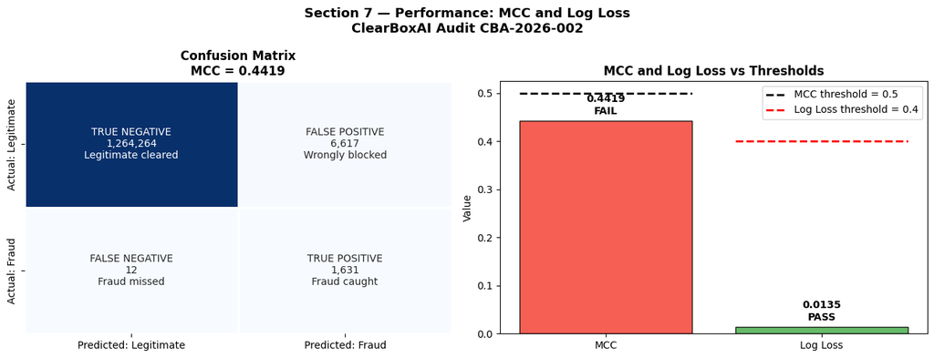

```python
# ── SECTION 7: PERFORMANCE EVALUATION ────────────────────────────────────────
mcc = matthews_corrcoef(y_test, y_pred)
ll  = log_loss(y_test, y_prob)
cm_out = confusion_matrix(y_test, y_pred)
tn, fp, fn, tp = cm_out.ravel()

precision = tp / (tp + fp) if (tp + fp) > 0 else 0
recall    = tp / (tp + fn) if (tp + fn) > 0 else 0

print('=' * 60)
print('PERFORMANCE METRICS — MCC AND LOG LOSS')
print('=' * 60)
print(f'\nMCC      = {mcc:.4f} | Threshold > {THRESHOLDS["MCC"]} '
      f'| {"PASS" if mcc > THRESHOLDS["MCC"] else "FAIL"}')
print(f'Log Loss = {ll:.4f} | Threshold < {THRESHOLDS["LOG_LOSS"]} '
      f'| {"PASS" if ll < THRESHOLDS["LOG_LOSS"] else "FAIL"}')
print(f'\nConfusion Matrix Breakdown:')
print(f'  Legitimate correctly cleared : {tn:>10,}')
print(f'  Legitimate wrongly blocked   : {fp:>10,}  (False Alarms)')
print(f'  Fraud missed completely      : {fn:>10,}  (Escaped Fraudsters)')
print(f'  Fraud correctly caught       : {tp:>10,}')
print(f'\n  Precision: {precision:.4f}')
print(f'  Recall   : {recall:.4f}')

print('\nPer-group MCC breakdown (ClearBoxAI Internal):')
for g in ['Low-Balance', 'Mid-Balance', 'High-Balance']:
    mask  = s_test['balance_group'].astype(str) == g
    fraud = y_test[mask].sum()
    if fraud > 1:
        g_mcc = matthews_corrcoef(y_test[mask], y_pred[mask])
        print(f'  {g:<14}: MCC = {g_mcc:.4f} ({fraud} fraud cases in test)')
    else:
        print(f'  {g:<14}: MCC = N/A (insufficient fraud cases: {fraud})')

# Visualization
fig, axes = plt.subplots(1, 2, figsize=(13, 5))
fig.suptitle(
    'Section 7 — Performance: MCC and Log Loss\n'
    'ClearBoxAI Audit CBA-2026-002',
    fontsize=13, fontweight='bold'
)

cm_labels = np.array([
    [f'TRUE NEGATIVE\n{tn:,}\nLegitimate cleared',
     f'FALSE POSITIVE\n{fp:,}\nWrongly blocked'],
    [f'FALSE NEGATIVE\n{fn:,}\nFraud missed',
     f'TRUE POSITIVE\n{tp:,}\nFraud caught']
])
sns.heatmap(cm_out, annot=cm_labels, fmt='', ax=axes[0], cmap='Blues',
            cbar=False,
            xticklabels=['Predicted: Legitimate', 'Predicted: Fraud'],
            yticklabels=['Actual: Legitimate', 'Actual: Fraud'],
            linewidths=1)
axes[0].set_title(f'Confusion Matrix\nMCC = {mcc:.4f}', fontweight='bold')

metric_vals   = [mcc, ll]
metric_thresh = [THRESHOLDS['MCC'], THRESHOLDS['LOG_LOSS']]
metric_pass   = [mcc > THRESHOLDS['MCC'], ll < THRESHOLDS['LOG_LOSS']]
bar_colors    = ['#4CAF50' if p else '#F44336' for p in metric_pass]

bars = axes[1].bar(['MCC', 'Log Loss'], metric_vals,
                   color=bar_colors, edgecolor='black', alpha=0.85)
axes[1].plot([-0.4, 0.4], [THRESHOLDS['MCC']] * 2, 'k--', lw=2,
             label=f'MCC threshold = {THRESHOLDS["MCC"]}')
axes[1].plot([0.6, 1.4], [THRESHOLDS['LOG_LOSS']] * 2, 'r--', lw=2,
             label=f'Log Loss threshold = {THRESHOLDS["LOG_LOSS"]}')
for bar, val, passed in zip(bars, metric_vals, metric_pass):
    axes[1].text(bar.get_x() + bar.get_width() / 2, bar.get_height() + 0.01,
                 f'{val:.4f}\n{"PASS" if passed else "FAIL"}',
                 ha='center', va='bottom', fontsize=10, fontweight='bold')
axes[1].set_title('MCC and Log Loss vs Thresholds', fontweight='bold')
axes[1].set_ylabel('Value')
axes[1].legend()

plt.tight_layout()
plt.savefig('fig_perf_01_mcc_logloss.png', dpi=150, bbox_inches='tight')
plt.show()
```

```
============================================================
DISCRIMINATION POWER — PR-AUC AND KS STATISTIC
============================================================

PR-AUC  = 0.9357 | Threshold > 0.7 | PASS
  Random baseline: 0.0013
  Model is 725x better than a random classifier

KS Stat = 0.9916 | Threshold > 0.3 | PASS
  Maximum score separation at score = 0.4118
```

[output not shown]

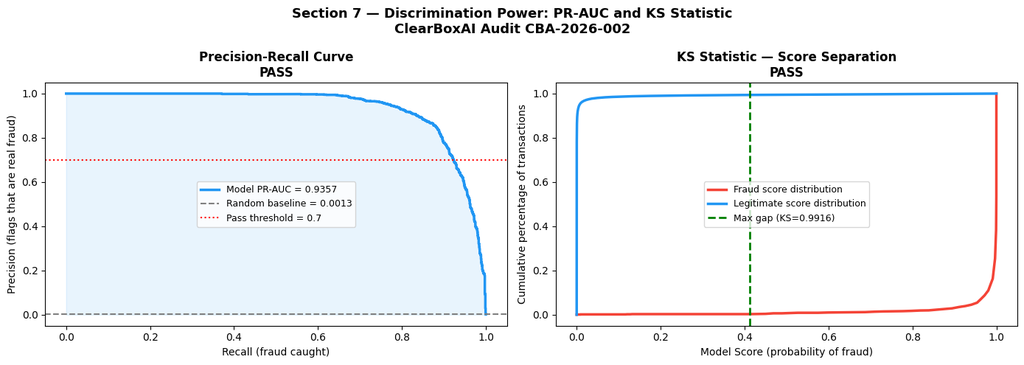

```python
# ── SECTION 7: PR-AUC AND KS STATISTIC ───────────────────────────────────────
# These measure discrimination power across all possible thresholds,
# not just at the default 0.5 cutoff.

prec_v, rec_v, _ = precision_recall_curve(y_test, y_prob)
pr_auc = auc(rec_v, prec_v)

fraud_scores = y_prob[y_test.values == 1]
legit_scores  = y_prob[y_test.values == 0]
ks_stat, _    = ks_2samp(fraud_scores, legit_scores)

sorted_scores = np.sort(y_prob)
sample_idx    = np.linspace(0, len(sorted_scores) - 1, 5000, dtype=int)
s_sample      = sorted_scores[sample_idx]
f_cdf = np.array([np.mean(fraud_scores <= s) for s in s_sample])
l_cdf = np.array([np.mean(legit_scores  <= s) for s in s_sample])
ks_score = s_sample[np.argmax(np.abs(f_cdf - l_cdf))]

print('=' * 60)
print('DISCRIMINATION POWER — PR-AUC AND KS STATISTIC')
print('=' * 60)
print(f'\nPR-AUC  = {pr_auc:.4f} | Threshold > {THRESHOLDS["PR_AUC"]} '
      f'| {"PASS" if pr_auc > THRESHOLDS["PR_AUC"] else "FAIL"}')
print(f'  Random baseline: {y_test.mean():.4f}')
print(f'  Model is {pr_auc / y_test.mean():.0f}x better than a random classifier')
print(f'\nKS Stat = {ks_stat:.4f} | Threshold > {THRESHOLDS["KS"]} '
      f'| {"PASS" if ks_stat > THRESHOLDS["KS"] else "FAIL"}')
print(f'  Maximum score separation at score = {ks_score:.4f}')

fig, axes = plt.subplots(1, 2, figsize=(14, 5))
fig.suptitle(
    'Section 7 — Discrimination Power: PR-AUC and KS Statistic\n'
    'ClearBoxAI Audit CBA-2026-002',
    fontsize=13, fontweight='bold'
)

axes[0].plot(rec_v, prec_v, color='#2196F3', lw=2.5,
             label=f'Model PR-AUC = {pr_auc:.4f}')
axes[0].axhline(y_test.mean(), color='gray', linestyle='--',
                label=f'Random baseline = {y_test.mean():.4f}')
axes[0].axhline(THRESHOLDS['PR_AUC'], color='red', linestyle=':',
                label=f'Pass threshold = {THRESHOLDS["PR_AUC"]}')
axes[0].fill_between(rec_v, prec_v, alpha=0.1, color='#2196F3')
axes[0].set_xlabel('Recall (fraud caught)')
axes[0].set_ylabel('Precision (flags that are real fraud)')
axes[0].set_title('Precision-Recall Curve\nPASS', fontweight='bold')
axes[0].legend(fontsize=9)

axes[1].plot(s_sample, f_cdf, color='#F44336', lw=2.5, label='Fraud score distribution')
axes[1].plot(s_sample, l_cdf, color='#2196F3', lw=2.5, label='Legitimate score distribution')
axes[1].axvline(ks_score, color='green', linestyle='--', lw=2,
                label=f'Max gap (KS={ks_stat:.4f})')
axes[1].set_xlabel('Model Score (probability of fraud)')
axes[1].set_ylabel('Cumulative percentage of transactions')
axes[1].set_title('KS Statistic — Score Separation\nPASS', fontweight='bold')
axes[1].legend(fontsize=9)

plt.tight_layout()
plt.savefig('fig_perf_02_prauc_ks.png', dpi=150, bbox_inches='tight')
plt.show()
```

## [Performance findings]

| Metric | Value | Threshold | Result |
| --- | --- | --- | --- |
| MCC | 0.4419 | above 0.50 | FAIL |
| Log Loss | 0.0135 | below 0.40 | PASS |
| PR-AUC | 0.9357 | above 0.70 | PASS |
| KS Statistic | 0.9916 | above 0.30 | PASS |

## Model Performance Evaluation — MCC Analysis

Three of four performance metrics pass. **Matthews Correlation Coefficient (MCC)** fails.

The reason is visible in the confusion matrix. The model catches **1,631 out of 1,643 actual fraud cases** and has a recall rate of **99.27%**, which is exceptional. However, it also wrongly blocks **6,617 legitimate customers**. Of everything the model flags as fraud, only **19.77%** is actually fraud.

MCC accounts for both sides of that tradeoff and penalises the high false positive count.

This is not a catastrophic finding. High recall with lower precision is a deliberate tradeoff in fraud detection, most operators would rather over-flag and review than miss real fraud. However, it does indicate that the model's **decision threshold requires calibration before deployment**. The precision issue will be addressed in the *Deployment Readiness* section.

## Per-Group MCC Breakdown

| Group | MCC | Fraud Cases (Test Set) |
| --- | --- | --- |
| Low-Balance | 0.1245 | 6 |
| Mid-Balance | 0.2192 | 225 |
| High-Balance | 0.6155 | 1,412 |

High-Balance users achieve an MCC of **0.6155** — strong performance.  
Mid-Balance drops to **0.2192** — noticeably weaker.  
Low-Balance sits at **0.1245** — barely above random guessing, based on just **6 fraud cases**.

## Structural Performance Insight

This gradient confirms the narrative established in both the proxy detection and E.D.A sections:

> The more fraud examples a group contributes during training, the better the model performs for that group.
- High-Balance: **5,738 training examples → MCC 0.62**
- Low-Balance: **35 training examples → MCC 0.12**

The relationship is direct, and the consequence is visible even before formal fairness metrics are applied.

## Interpretation

This is the **accuracy paradox made concrete**:

- Aggregate metrics appear strong
- MCC exposes the precision problem
- Per-group MCC reveals **structural underperformance**

Even MCC understates the severity for Low-Balance users, because **6 test cases is too small a sample** to fully capture failure behavior. A dedicated fairness analysis is required to properly quantify the risk.

## Regulatory Mapping

| Regulation / Standard | Provision | Status |
| --- | --- | --- |
| BoG CISD 2026 | Annexure E §g(iii)(1) — Functional & performance testing | Complete |
| NIST AI RMF 1.0 | MEASURE 2.3 — Performance criteria measured | Complete |
| NIST AI RMF 1.0 | §3.1 — Valid & Reliable characteristic | Complete |

## Risk Assessment

**Risk Level: MEDIUM**

- MCC failure driven by high false positive rate
- Threshold calibration required before deployment
- Per-group MCC confirms structural underperformance for Low-Balance users

A full fairness assessment follows in the next section.

**Auditor:** Kwadwo Amponsah  
**Organisation:** ClearBoxAI  
**Date:** April 2026

```python
df.to_csv('checkpoint_v2.csv', index=False)
print("Checkpoint v2 saved.")
```

```
Checkpoint v2 saved.
```